# Homework 1

Natalie Sawtelle

2025-09-09

# Problem 1: Chick Weights

```r
chick_weights <- chickwts |>
  mutate(weight_oz = weight/28.35)
chick_anova_g <- aov(weight ~ feed, data=chick_weights)
chick_anova_oz <- aov(weight_oz ~ feed, data=chick_weights)
```

```r
summary(chick_anova_g)
```

```
##             Df Sum Sq Mean Sq F value   Pr(>F)
## feed         5 231129   46226   15.37 5.94e-10 ***
## Residuals   65 195556    3009
## ---
## Signif. codes:  0 '***' 0.001 '**' 0.01 '*' 0.05 '.' 0.1 ' ' 1
```

```r
summary(chick_anova_oz)
```

```
##             Df Sum Sq Mean Sq F value   Pr(>F)
## feed         5  287.6   57.51   15.37 5.94e-10 ***
## Residuals   65  243.3    3.74
## ---
## Signif. codes:  0 '***' 0.001 '**' 0.01 '*' 0.05 '.' 0.1 ' ' 1
```

**Both tests result in the same F and P-values, this shows that unit conversion does not affect the results of hypothesis testing.**

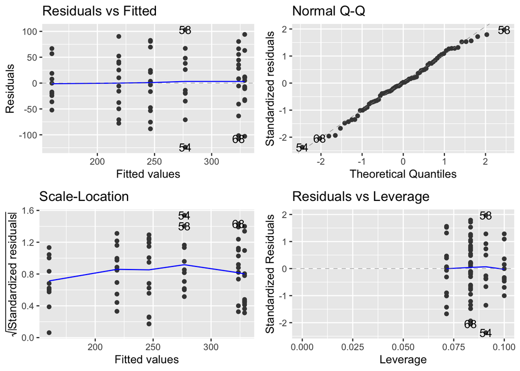

```r
autoplot(chick_anova_g)
```

**The spread of residuals looks uneven across the groups, this suggests possible violations of the equal variance assumption.**

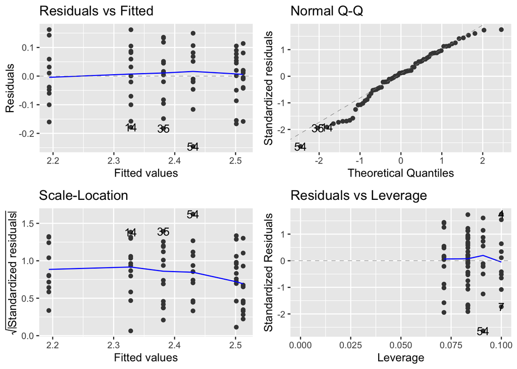

```r
chick_log_anova <- aov(log10(weight) ~ feed, data=chick_weights)
autoplot(chick_log_anova)
```

**The Residuals vs Fitted and Scale-Location plots show uniform spread. This indicates that the log-transformation improves the constant variance assumption compared to the not transformed model.**

```r
summary(chick_log_anova)
```

```
##             Df Sum Sq Mean Sq F value   Pr(>F)
## feed         5 0.7764 0.15528   16.27 2.21e-10 ***
## Residuals   65 0.6202 0.00954
## ---
## Signif. codes:  0 '***' 0.001 '**' 0.01 '*' 0.05 '.' 0.1 ' ' 1
```

**Both conclude that Feed type significantly affects chick weight. Task two gives out large sums of squares, while Task 5 gives out small sums of squares.**

**task 6: Transforming the response variable makes the analysis more statistically valid by meeting model assumptions, but it does this at the cost of the ability to easily interpret the results.**

#Problem 2:Popcorn

- What are the **Experimental Units** in this study?
  - **Bags of kernels**
- What is the **response variable** in this study?
  - **number of kernels poped**
- What is the **factor** in this study?
  - **oil amount**
- How many **factor levels** are there?
  - **none, 1/2 teaspoon ,1 teaspoon**
- What are the **treatments**?
  - **Popcorn popped with no oil, with 1/2 teaspoon of oil, and with 1 teaspoon of oil**

```r
Popcorn_study <- read.csv("popcorn.csv")
```

```r
Popcorn_study_ordered <- Popcorn_study |>
  arrange(desc(Oil), Kernels)
```

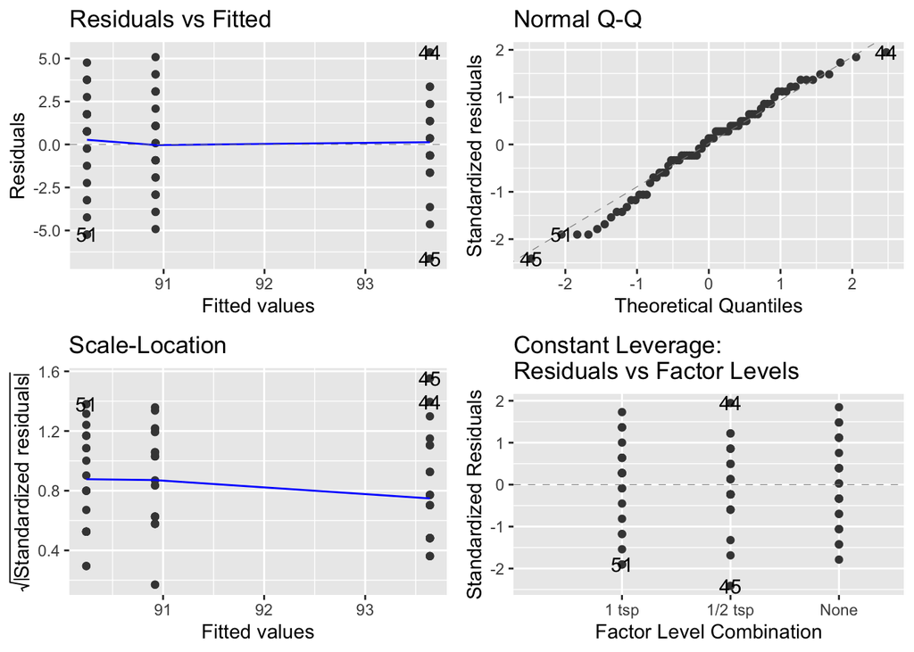

```r
anova_model <- aov(Kernels ~ Oil, data = Popcorn_study)
autoplot(anova_model)
```

**Since the p-value is much smaller than 0.05, we reject the null hypothesis that oil has no effect.**

```r
summary(anova_model)
```

```
##             Df Sum Sq Mean Sq F value   Pr(>F)
## Oil          2  161.8   80.92   10.26 0.000121 ***
## Residuals   72  568.2    7.89
## ---
## Signif. codes:  0 '***' 0.001 '**' 0.01 '*' 0.05 '.' 0.1 ' ' 1
```

**The Residuals vs Fitted plot suggests no violation and the Normal Q-Q plot is approximately normal.**

# Problem 3: Ant Pesticide

- What are the **Experimental Units** in this study?
  - **Colonies**
- What is the **response variable** in this study?
  - **Number of ants killed**
- What is the **factor** in this study?
  - **Pesticide**
- How many **factor levels** are there?
  - **types A, B, C, and D**
- What are the **treatments**?
  - **Colonies treated with pesticide type A, type B, type C, or type D**

```r
ant_pesticide_study <- read.csv("ant_pesticide.csv")
```

```r
ant_pesticide_study_ordered <- ant_pesticide_study |>
  mutate(Pesticide = factor(Pesticide)) |>
  arrange(Pesticide, DeadAnts)
```

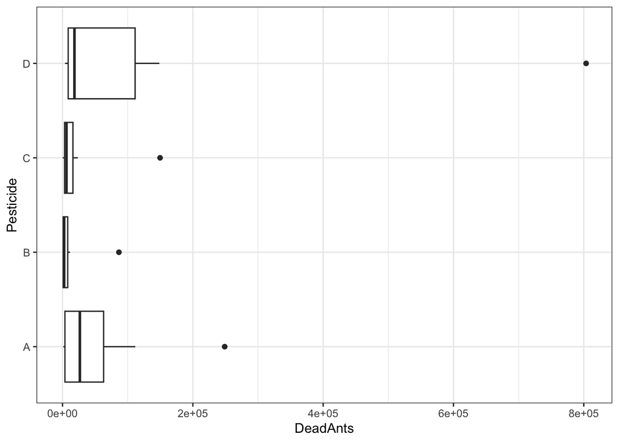

```r
ggplot(ant_pesticide_study_ordered) +
  geom_boxplot(aes(x=DeadAnts, y=Pesticide)) +
  theme_bw()
```

```r
ant_anova <- aov(DeadAnts ~ Pesticide, data = ant_pesticide_study_ordered)
summary(ant_anova)
```

```
##             Df    Sum Sq   Mean Sq F value Pr(>F)
## Pesticide    3 6.817e+10 2.272e+10     1.3  0.289
## Residuals   36 6.292e+11 1.748e+10
```

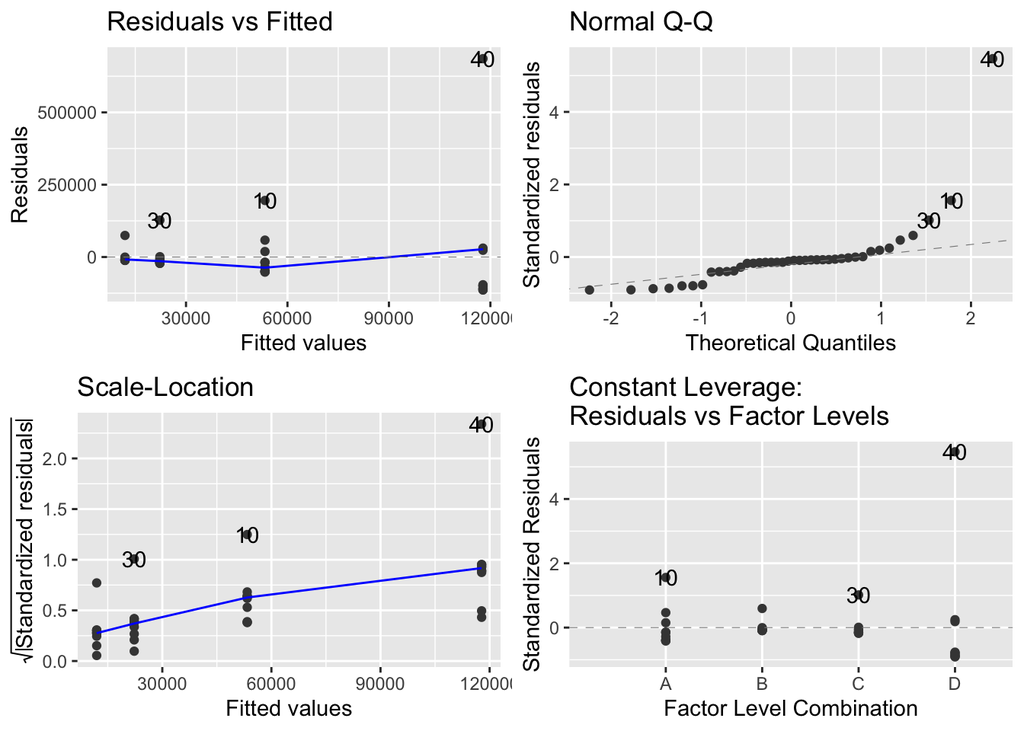

```r
autoplot(ant_anova)
```

**Based on this study, there is no significant differences between pesticides type A, B, C, and D. However, there are some indications that types A and D are better than types B and C.**